# COYUNTURA ECONÓMICA DE GALICIA.

## TERCER TRIMESTRE DE 2022

### Autores: Fernando de Rojas Ojeda y Lucía Rubio Pérez

### ÍNDICE

1.Resumen

2.Actividad productiva

- Tasa de variación interanual del PIB de Galicia y España
- Tasa de de variación interanual del Índice de Producción Industrial
- Índice de Confianza Empresarial

3.Demanda

- Índice de Confianza del Consumidor
- Créditos a las Viviendas
- Tasa de variación interanual de las Exportaciones de España y Galicia
- Tasa de variación interanual de las Importaciones de España y Galicia
- Balanza Comercial

4.Mercado de Trabajo

- Tasa de Actividad en España y Galicia
- Tasa de Empleo en España y Galicia
- Tasa de Paro en España y Galicia
- Tasa de Temporalidad en España y Galicia
- Afiliados a la Seguridad Social en España y Galicia
- Tasa de variación interanual de las Afiliaciones a la Seguridad Social
- Número de Parados en España y Galicia
- Tasa de variación interanual del Número de Parados en España y Galicia

5.Precios y costes

- Índice Precios del Consumidor
- Costes Laborales (Salariales y No Salariales) en España y Galicia

6.Impacto de la crisis y previsiones

- Predicción de Afiliados a la Seguridad Social
- Previsión del Número de Parados

7.Tabla con los indicadores más relevantes en 2022

# 1. Resumen

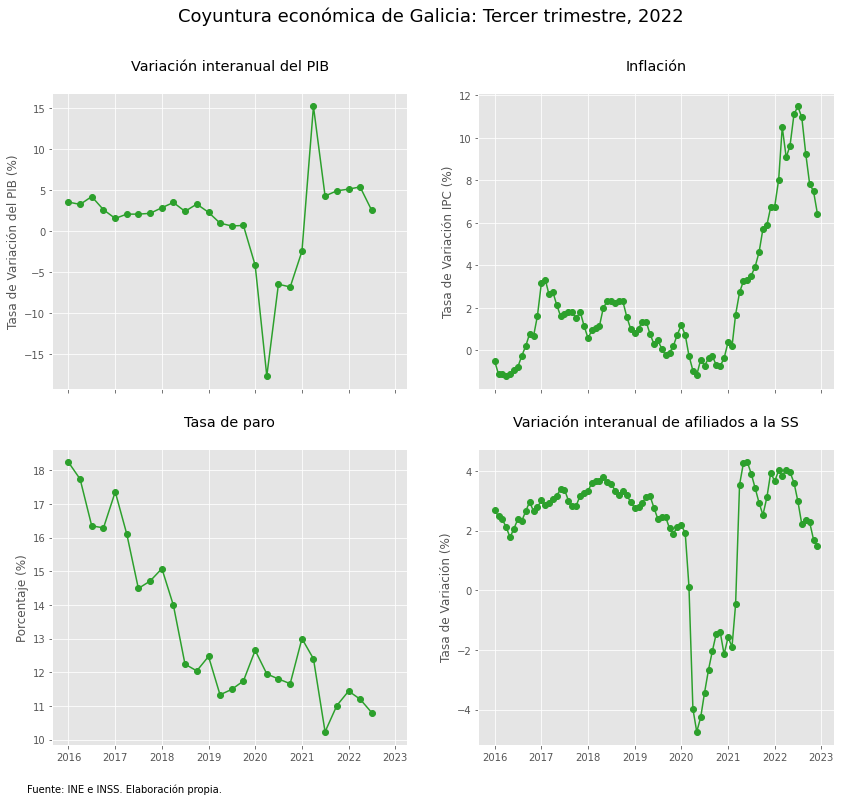

En 2022, el PIB se recuperó, alcanzando una tasa de crecimiento en el segundo trimestre de 2022 del 5,3% respecto el mismo trimestre del año anterior.

La inflación ha estado en niveles muy altos, como consecuencia de las laxas políticas monetarias de los bancos centrales y del conflicto Rusia-Ucrania. Se observa cierta tendencia a la moderación de precios.

Respecto al mercado de trabajo, la tasa de paro continúa con la tendencia descendiente pre-pandemia.

# 2. Actividad productiva

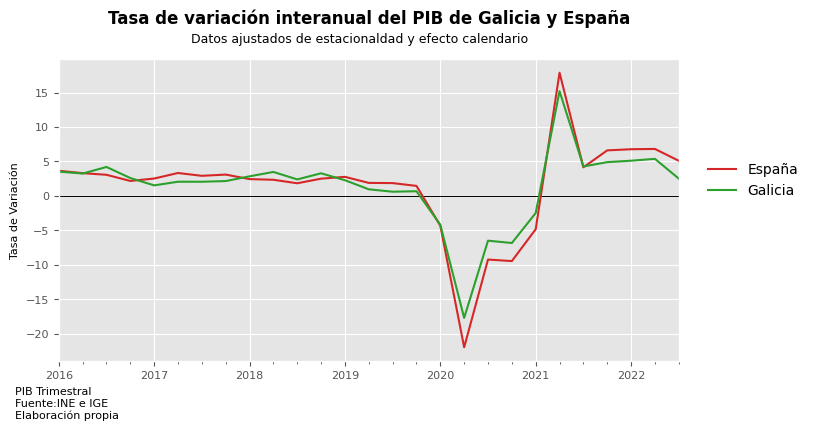

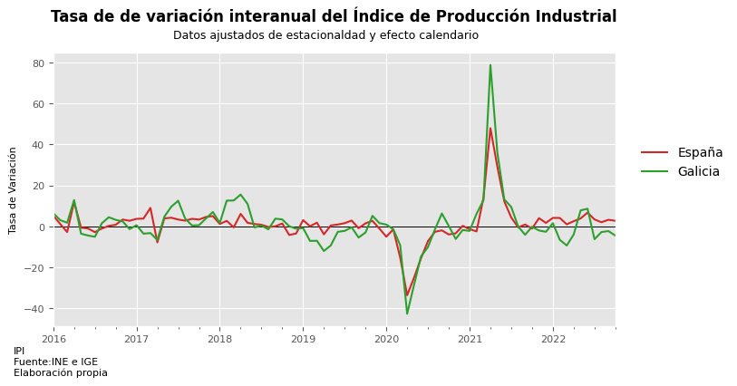

Podemos apreciar un comportamiento similar a la variación del PIB. Con una fuerte caída en 2020 y una posterior recuperación en 2021.

A partir del segundo trimestre de 2021, se frenó el crecimiento. Así, terminó 2022 con unas variaciones similiares a las previas a la crisis.

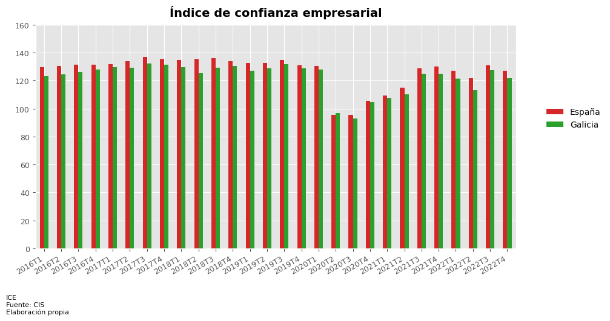

Las consecuencias de la crisis sanitaria son notables en el ICE, con un claro descenso en el segundo trimestre de 2020.

A lo largo de 2021, volvió a crecer, alcanzando los niveles previos a la crisis.

# 3. DEMANDA

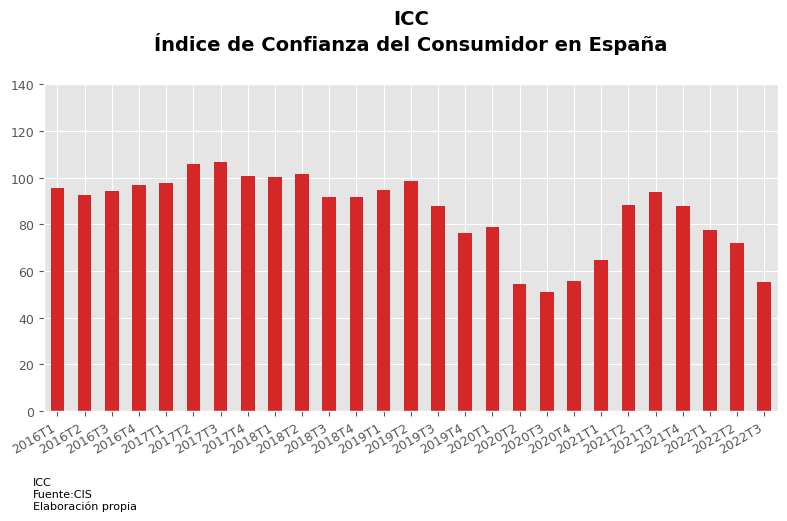

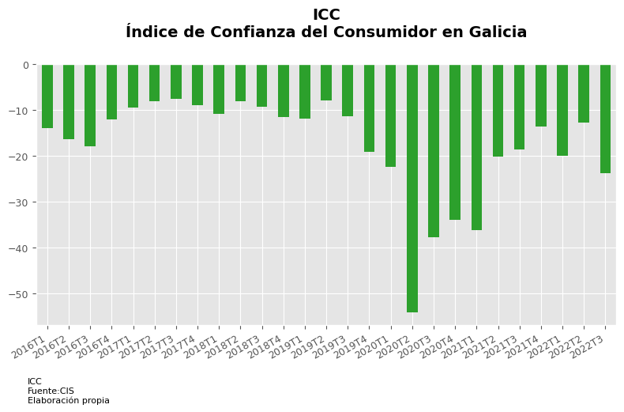

El ICC venía presentando caídas desde 2019. La llegada de la pandemia y la crisis sanitaria provocaron una caída más abrupta.

No fue hasta el segundo trimestre de 2021 que comenzó a retomar el crecimiento.

Al llegar la guerra en Ucrania en el primer trimestre de 2022, volvió a caer la confianza de los consumidores.

## Créditos a las Viviendas

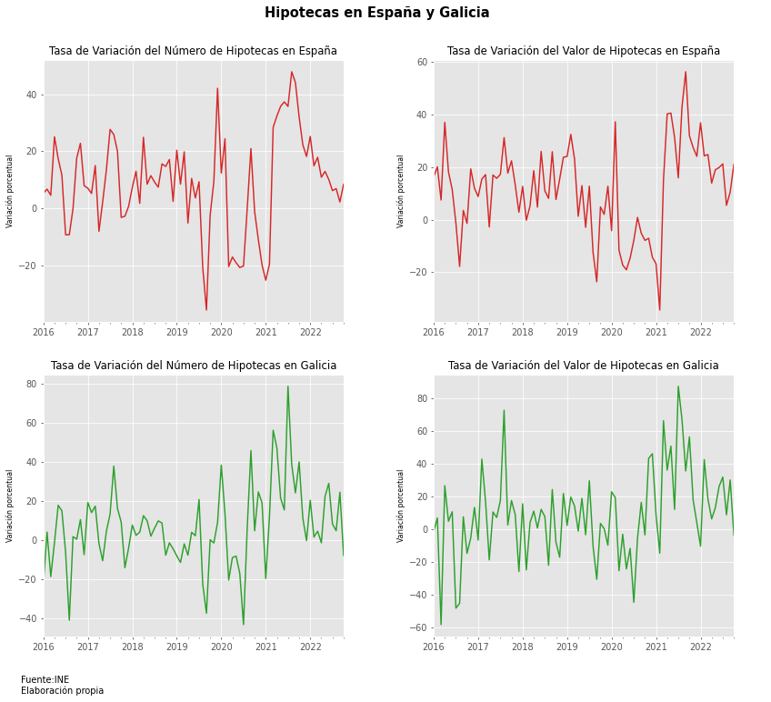

Podemos apreciar fuertes variaciones a medida que avanza la crisis sanitaria, momento en el que ocurren las variaciones más abruptas.

Las variaciones más importantes las tenemos en 2021, en el que se firman más hipotecas y de mayor valor. En 2022, con la subida de tipos de interés, vemos como las tasas de variación decrecen.

## Comercio Exterior

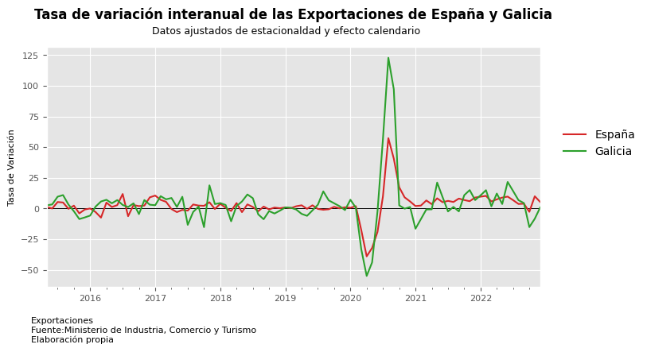

## Tasa de variación interanual de las Importaciones de España y Galicia

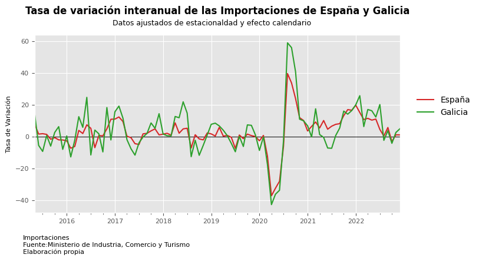

## Balanza Comercial

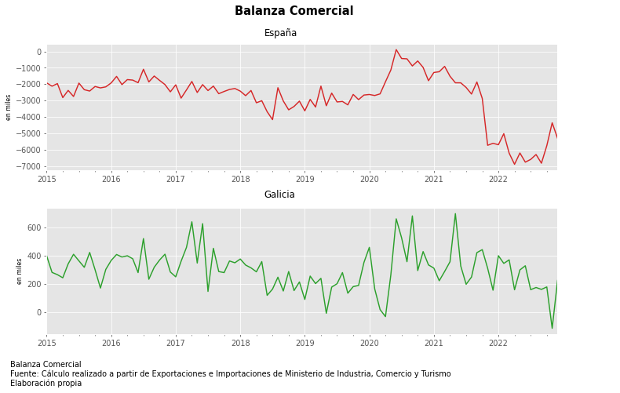

# 4. Mercado de trabajo

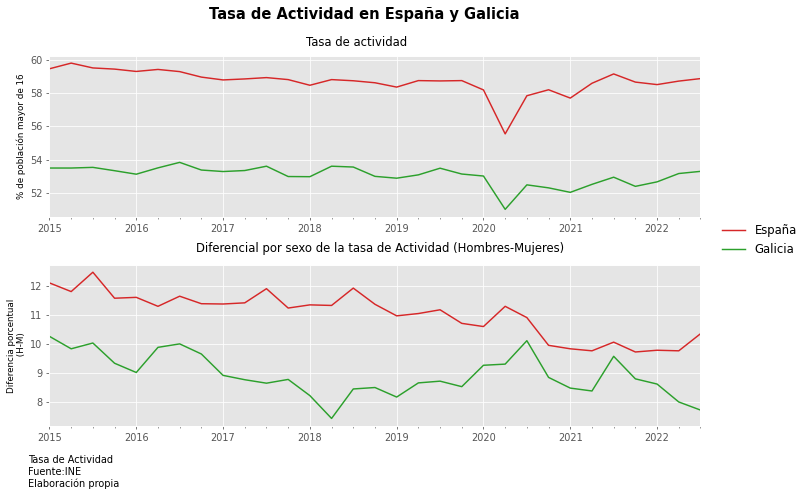

Cabe destacar el descenso provocado por la crisis sanitaria. Pese a la crisis, poco tiempo más tarde se recuperaron los niveles previos.

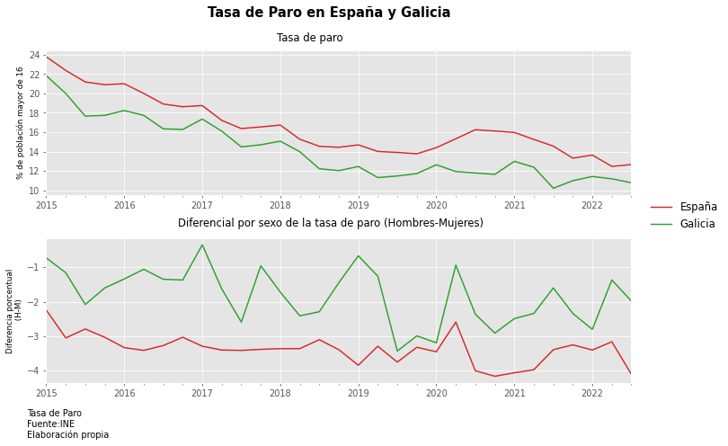

La tasa de paro en Galicia se mantiene inferior a la de España, con tendencia a la baja en ambas economías.

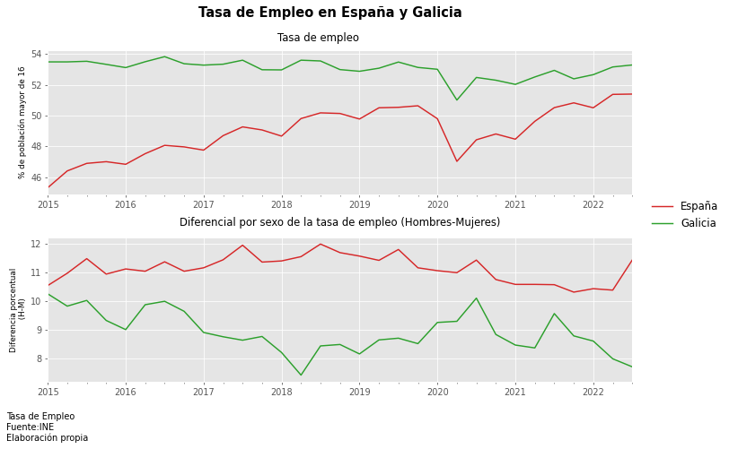

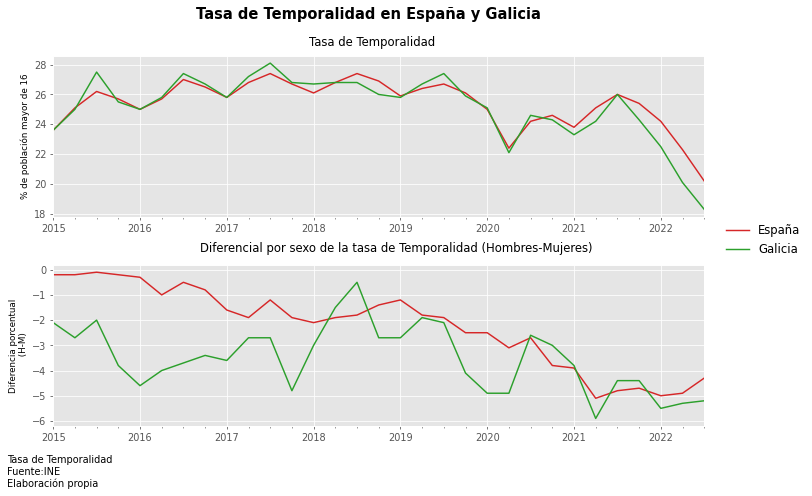

La tasa de temporalidad para Galicia y España siguen el mismo comportamiento, y son tasas similares.

Se puede observar que la situación de la mujer ha empeorado relativamente a lo largo de este periodo.

## Afiliados a la Seguridad Social en España y Galicia

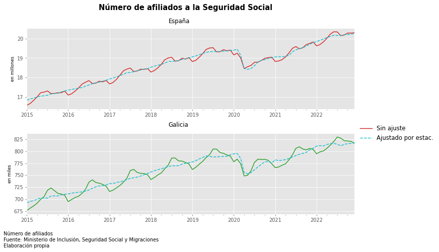

El número de afiliados a la Seguridad Social muestra una evolución creciente. Todo ello a pesar del impacto del Covid-19.

Presenta una caída en el primer trimestre de 2020, punto a partir del cual no deja de crecer.

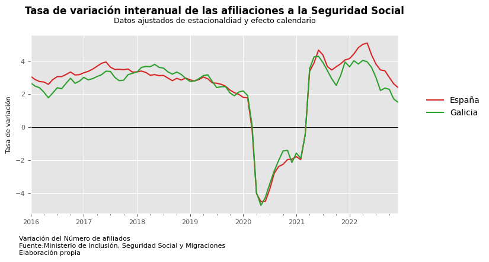

## Número de Parados en España y Galicia

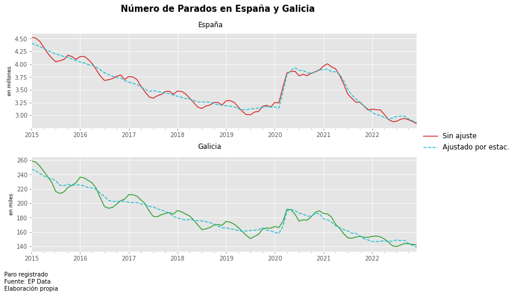

Tanto España como Galicia vieron empeorar su situación con la llegada de la crisis sanitaria, aumentando el número de personas en situación de paro. Esta consecuencia fue más grave en España, con una mayor subida en todo 2020.

No fue hasta principios de 2021, cuando las medidas cautelares cesaron, que el número de parados volvió a decrecer.

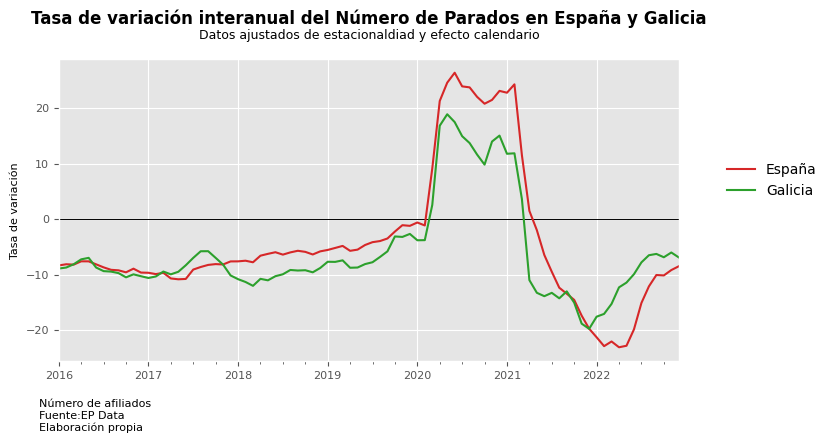

El comportamiento de Galicia es bastante similar al caso español, con tasas negativas antes y después de la pandemia. Durante esta, las variaciones experimentaron un crecimiento, pero no tan alto como el de España.

# 5. Precios y costes

## Índice Precios del Consumidor

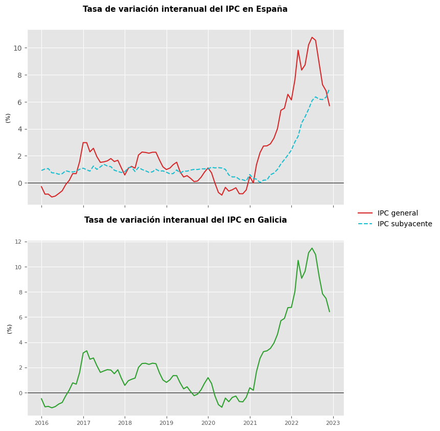

Desde el año 2021 la inflación ha experimentado un destacado crecimiento, moderándose desde mediados de 2022.

La inflación continúa bastante por encima del objetivo del 2%, pero a unas tasas más moderadas.

## Costes Laborales

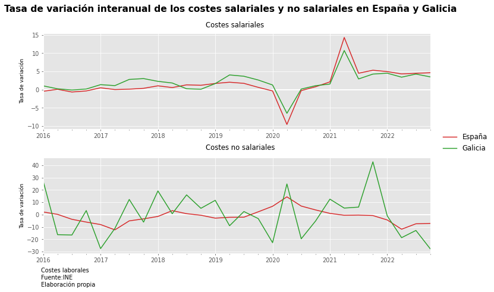

El comportamiento de los costes salariales son similares en España y Galicia desde el inicio de la serie, con una caída en el segundo trimestre de 2020 y una posterior recuperación.

El coste no salarial de Galicia presenta una mayor volatilidad.

# 6. Impacto de la crisis y previsiones

## Predicción de Afiliados a la Seguridad Social

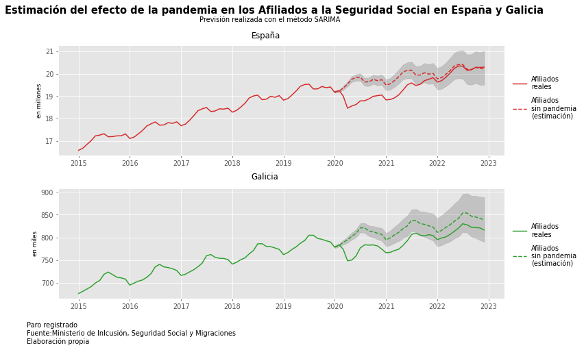

El número de afiliados a la Seguridad Social hubiera continuado creciendo en España sin la existencia de la pandemia. No obstante, a mediados de 2022 el nivel de afiliaciones real iguala al que se estima que hubiera habido sin pandemia.

## Predicción del Número de Parados

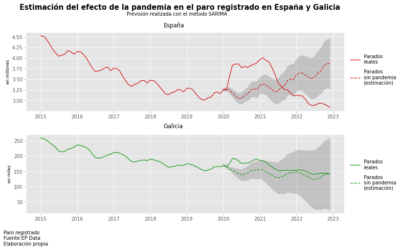

La predicción nos muestra una muy notable recuperación del paro registrado en España.

En el caso de Galicia, la crisis sanitaria tuvo un impacto menos severo y se observa que la serie real ha convergido a la estimada sin pandemia.

## Tabla resumen con los indicadores más relevantes

[output not shown]